# Wellcome Data Cleansing Project

This is a data-cleaning exercise for my thinkful Data Science Course Raj Prasad, May 2019

[html version](https://daddyprasad5.github.io/Wellcome.html) - with all the code hidden away for a quick read

[jupyter notebook version](https://github.com/daddyprasad5/thinkful/blob/master/Wellcome.ipynb) - with all the code exposed in an interactive notebook

## Tasks:

- determine the five most common journals
- determine the total articles for each of the above.
- calculate the mean, median, and standard deviation of the open-access cost per article for each journal.
- (bonus) identify the open access prices paid by subject area.

(You will need to do considerable data cleaning in order to extract accurate estimates. You may may want to look into data encoding methods if you get stuck.)

## Import & Clean the Data

- I converted the given file to unicode 8 by opening it in Apple's Numbers application and saving it as unicode 8 (feels like cheating, but it worked.)
- I cleaned the cost column - removing '£' and punctution and converting to numeric
- I used ngrams, tfidf and cosine similarity to normalize the journal names

The last of these was more involved. I followed the process defined [here](https://bergvca.github.io/2017/10/14/super-fast-string-matching.html) by Chris van den Berg.

```python
#imports, file load, and print header of raw data↔
```

```python
#a look at the starting table↔
```

|  | PMID/PMCID | Publisher | Journal title | Article title | COST (£) charged to Wellcome (inc VAT when charged) |
| --- | --- | --- | --- | --- | --- |
| 0 | NaN | CUP | Psychological Medicine | Reduced parahippocampal cortical thickness in ... | £0.00 |
| 1 | PMC3679557 | ACS | Biomacromolecules | Structural characterization of a Model Gram-ne... | £2381.04 |
| 2 | 23043264 PMC3506128 | ACS | J Med Chem | Fumaroylamino-4,5-epoxymorphinans and related ... | £642.56 |
| 3 | 23438330 PMC3646402 | ACS | J Med Chem | Orvinols with mixed kappa/mu opioid receptor a... | £669.64 |
| 4 | 23438216 PMC3601604 | ACS | J Org Chem | Regioselective opening of myo-inositol orthoes... | £685.88 |

```
number of costs >100k is  49
```

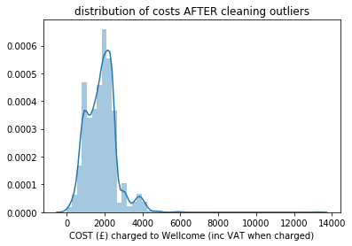

```python
#clean the cost column↔
```

```python
#Clean the journal title column↔
```

```python
#Sample of cleaned data (only showing a few rows with cleaned titles)↔
```

|  | PMID/PMCID | Publisher | Journal title | Article title | COST (£) charged to Wellcome (inc VAT when charged) | Normalized Journal Title |
| --- | --- | --- | --- | --- | --- | --- |
| 16 | 22610094 | AMBSB | journal of biological chemistry | Annexin-1 interaction with FPR2/ALX | 265.67 | the journal of biological chemistry |
| 31 | PMID:23281892 PMC3579312 | American Chemical Society | journal of medicinal chemistry | A class of 5-nitro-2-furancarboxylamides with ... | 321.12 | journal of medicinal chemistry |
| 33 | PMC3593610 | American Chemical Society | journal of the american chemical society | Chemical and structural analysis of an antibod... | 1626.14 | american chemical society |
| 42 | 23576705, PMC3727040 | American Physiological Society | the journal of neurophysiology | Integration of Texture and Disparity Cue to Su... | 1276.60 | journal of neurophysiology |
| 43 | NaN | American Psychiatric Association | american journal of psychiatry | Methamphetamine-induced disruption of frontost... | 2351.73 | americal journal of psychiatry |